# Week 26 - Invasive Species in Africa

Luis de Sousa

September 27, 2018

My analysis for week 26 of #TidyTuesday

## Data Sources

[Paini et al, 2016](http://www.pnas.org/content/113/27/7575) report on “Global threat to agriculture from invasive species”. Developing countries in Africa are some of the most sensitive to invasive species damage to agriculture.

Table data from [tables](http://www.pnas.org/content/113/27/7575/tab-figures-data) in the Appendix.

All invasive species data for Africa from http://www.griis.org/.

## Raw data

Raw data is what the “raw” data looks like from the paper’s tables. If you want to practice your `tidy` skills this would be a good starting place! An example tidying script is also posted if you get stuck.

```r
#janitor::clean_names() - Resulting names are unique and consist only of the _ character, numbers, and letters.

#afr_species is missing from raw directory
afr_species <- read.csv('africa_species.csv') %>% janitor::clean_names()

table1 <- read.csv('raw/table1.csv') %>% janitor::clean_names()

table2 <- read.csv('raw/table2.csv') %>% janitor::clean_names()
table3 <- read.csv('raw/table3.csv') %>% janitor::clean_names()
table4 <- read.csv('raw/table4.csv') %>% janitor::clean_names()
table6 <- read.csv('raw/table6.csv') %>% janitor::clean_names()
```

## Table Data

Tidy and cleaned data for the tables from Paini et al, 2016.

- **Table 1**: Ranking of all threatened countries by overall invasion threat (`invasion_threat`).
- **Table 2**: Ranking of all threatened countries by total invasion cost (`invasion_cost`).
- **Table 3**: Ranking of all threatened countries by total invasion cost (`invasion_cost`) as a proportion (`gdp_proportion`) of mean GDP (`gdp_mean`).
- **Table 4**: Ranking of all **source** countries by total invasion cost (`invasion_cost`)
- **Table 6**: List of 140 species and their **maximum** recorded **percentage** impact on one of their known host crops (source: CABI Crop Protection Compendium)

```r
table_1 <- read.csv('table_1.csv')
table_2 <- read.csv('table_2.csv')
table_3 <- read.csv('table_3.csv')
table_4 <- read.csv('table_4.csv')
table_6 <- read.csv('table_6.csv')
```

```r
# download the file
#download.file("http://thematicmapping.org/downloads/TM_WORLD_BORDERS-0.3.zip", destfile="TM_WORLD_BORDERS-0.3.zip")

# unzip the file
#unzip("TM_WORLD_BORDERS-0.3.zip")

the_world <- st_read('TM_WORLD_BORDERS-0.3.shp')
```

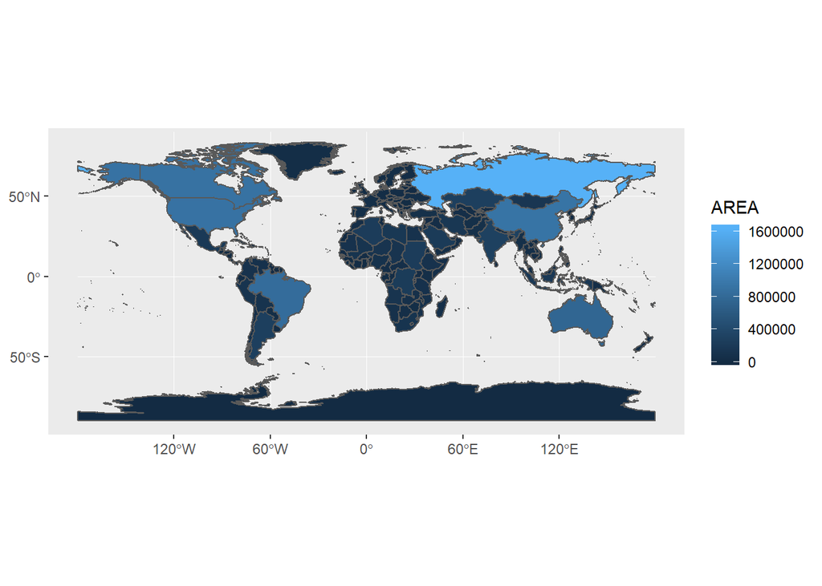

[figure not shown]

```r
ggplot(the_world) + geom_sf(aes(fill = AREA))
```

## Invasive Species by African Countries

Developing countries in Africa appear to be most vulnerable to invasive species damage to agriculture. `africa_species.csv` contains the known invasive species for African countries from `griis.org`.